# C12.40 サンドイッチ構造と設計

$$c^3 ( ) + c^2 \left[ 4t_F ( ) - \left\{ \right\} \right] + c \left[ 5t_F^2 ( ) - 2t_F \left\{ \right\} - [ ] \right] + \left[ 2t_F^3 ( ) - t_F^2 \left\{ \right\} - 2t_F [ ] \right] = 0$$

ここで、

$$[ ] = \frac{4L^2 (1 - \mu^2)}{\pi^2 E_F}, \quad \left\{ \right\} = \frac{2t_F M}{G'_C}$$

$$( ) = \frac{M^2}{\frac{n^2 \beta^2}{\eta} \left[ \frac{F_y}{\eta} - \frac{.00935 L^2 \pi^2 E_F}{n^2 R^2 M^2 (1 - \mu^2)} \right]}$$

$$M = 1 + n^2 \beta_1^2$$

## C12.11.1 例題

次の例題は、一軸圧縮荷重を受けるハニカムパネルの設計パラメータの計算方法を示している。

与条件:

1. 材料: PH15-7Mo (RH 1050) 室温にて
2. 特性:
   - $E_F = 30 \times 10^6$ psi
   - $E_C = 30 \times 10^6$ psi
   - $G_C = 10 \times 10^6$ psi
   - $F_{cy} = 190,000$ psi
   - $\mu = .3$
3. 形状および荷重:
   - $a = 20$ in.
   - $b = 20$ in.
   - $N = 6000$ lb/in.
   - $F_C = 190,000$ psi
   - 等厚面板
   - 単純支持パネル

計算:

1. $$t_F = \frac{N}{2F_C} = \frac{6000}{2 \times 190,000} = .016 \text{ in.}$$
2. $\eta = .32$ （図 C12.5.2b 参照）
3. $\eta_s = .7$ （図 C12.5.7b 参照）
4. $$\frac{t_C}{s} = .5 \left[ \frac{1.35 F_C}{(E_F \eta_s^3 E_C G_C)^{1/3}} \right]^{1.015} \quad \text{式 C12.10.6 参照}$$

$$\frac{t_C}{s} = .5 \left[ \frac{1.35 \times 190000}{(30 \times 10^6 \times .343 \times 30 \times 10^6 \times 10 \times 10^6)^{1/3}} \right]^{1.015}$$

$$\frac{t_C}{s} = .0083$$

$$G'_C = 2.43 (.0166)^{1.34} \times 10 \times 10^6 = 43800 \text{ psi}$$

6. $J = 10$ と仮定する。

   $K_C = 3.3$ （図 C12.5.10 参照）
7. $$c = \left[ \frac{4 F_C b^2 (1 - \mu^2)}{\pi^2 K_C \eta E_F} \right]^{1/2} - t_F \quad \text{式 C12.10.10 参照}$$

$$c = \left[ \frac{4 \times 190000 \times 400 \times .91}{\pi^2 \times 3.3 \times .32 \times 30 \times 10^6} \right]^{1/2} - .016$$

```
$c = .924$  in.
```

8. $$J = \frac{b^2 G'_C (c + 2t_F) 2 (1 - \mu^2)}{\pi^2 E_F t_F (c + t_F)^2}$$

$$J = \frac{400 \times 43800 (.924 + .032) 2 (.91)}{\pi^2 \times 30 \times 10^6 \times .016 (.924 + .016)^2}$$

```
$J = 7.28$

$K_C = 3.05$  （図 C12.5.10 参照）
```

9. $c$ を再計算する

   $c = .964$ in.
10. $J$ を再計算する

    $J = 7.33$

    $K_C = 3.05$
11. $c$ を再計算する

    $c = .964$ in.
12. 仮定した $J$ 対 計算された $J$ をプロットする

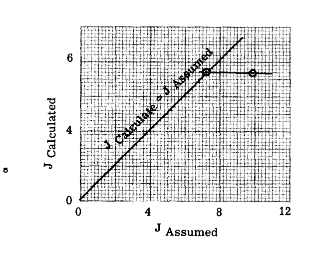

# C12.41

$K_C = 3.05$

14. $c$ を再計算する

    $c = .964$ in.
15. $c$ は十分に収束したため、最終回答として $c = .964$ を使用する。
16. パネルの剪断クリンプをチェックする

$$F_{cs} = \frac{G'_C (c + 2t_F)}{2t_F} \quad \text{式 C12.5.18 参照}$$

$$F_{cs} = \frac{43,800 (.964 + .032)}{.032} = 1,365,000 \text{ psi}$$

剪断クリンプは発生しない。

17. 最大コアセルサイズと箔の厚さを計算する。

$$s = .825 t_F (F_C / E_F \eta)^{-2/3} \quad \text{式 C12.10.1 参照}$$

$$s = .825 \times .016 \left( \frac{30 \times 10^6 \times .32}{190000} \right)^{2/3} = .181 \text{ in.}$$

$$c = .0083 \times .181 = .0015 \text{ in.}$$

これらの値は、入手可能な材料サイズに合わせるために、実際の設計において調整する必要がある。

## C12.11.2 例題

次の例題は、二軸圧縮および剪断荷重を受けるハニカムパネルの設計パラメータの計算方法を示している。

与条件:

1. 材料: PH15-7Mo (RH1050) 室温にて
2. 特性:
   - $E_F = 30 \times 10^6$ psi
   - $E_C = 30 \times 10^6$ psi
   - $G_C = 10 \times 10^6$ psi
   - $F_{cy} = 190000$ psi
   - $\mu = .3$
3. 形状および荷重
   - $a = 20$ in.
   - $b = 10$ in.
   - $N_x = 5000$ lb/in.
   - $N_y = 2000$ lb/in.
   - $N_{xy} = 2000$ lb/in.
   - $F_{c\text{max}} = 120000$ psi
   - 等厚面板
   - パネル端部単純支持

計算:

1. $$N_n = \frac{N_x + N_y}{2} \pm \sqrt{\left( \frac{N_x - N_y}{2} \right)^2 + N_{xy}^2} \quad \text{Sec. C1.6 式 10 参照}$$

$$N_n = \frac{5000 + 2000}{2} + \sqrt{\left( \frac{5000 - 2000}{2} \right)^2 + (2000)^2}$$

$$N_n = 6000 \text{ lb./in.}$$

2. $$t_F = \frac{N_n}{2F_{c\text{max}}} = \frac{6000}{2 \times 120000} = .025 \text{ in.}$$
3. $$\frac{F_{c\text{max}}}{F_{cy}} = .631 \quad \eta_s = .985 \quad \text{図 C12.5.7b 参照}$$
4. $$\frac{t_C}{s} = .5 \left[ \frac{1.35 F_{c\text{max}}}{(E_F \eta_s^3 E_C G_C)^{1/3}} \right]^{1.015} \quad \text{式 C12.10.6 参照}$$

$$\frac{t_C}{s} = .5 \left[ \frac{1.35 \times 120000}{(30 \times 10^6 \times .956 \times 30 \times 10^6 \times 10 \times 10^6)^{1/3}} \right]^{1.015}$$

$$\frac{t_C}{s} = .00368$$

5. 面のしわ寄り許容値をチェックする（Sec. C12.5.3.4 参照）

$$f_x = \frac{N_x}{2t_F} = \frac{5000}{2 \times .025} = 100000 \text{ psi}$$

$$f_{xy} = f_y = \frac{2000}{2 \times .025} = 40000 \text{ psi}$$

$$\frac{s}{t_C} = 272$$

$$\frac{F_{cw}}{\eta_s} = \frac{F_{sw}}{\eta_s} = 123000 \quad \text{図 C12.5.7a または 式 C12.5.10 参照}$$

$$\gamma = \frac{f_y}{f_x} = \frac{40000}{100000} = .4$$

$$\gamma_1 = \sqrt{1 - \gamma + \gamma^2} = .872 \quad \text{（C12.52 ページ参照）}$$

$$\frac{F_{cwx}}{\eta_s} = \frac{F_{cw}}{\eta_s \sqrt{\gamma_1} + \gamma^3} = 120500 \text{ psi}$$

$$F_{cwx} = 118500 \text{ psi} \quad \text{図 C12.5.7b 参照}$$

$$\gamma_1 = \sqrt{3} \quad \text{for } \frac{F_{sw}}{\eta_s}$$

$$F_{sw} = 97200 \text{ psi} \quad \text{図 C12.5.7b 参照}$$

$$M.S. = \frac{2}{R_a + \sqrt{R_a^2 + 4R_s^2}} - 1 \quad \text{式 C12.5.3.2 参照}$$

# C12.42 サンドイッチ構造と設計

$$R_a = \frac{f_x}{F_{cwx}} = \frac{100000}{118500} = .84$$

$$R_s = \frac{f_s}{F_{sw}} = \frac{40000}{97200} = .41$$

$$M.S. = \frac{2}{.84 + \sqrt{.84^2 + 4 \times .41^2}} - 1 = -.004$$

マージン・オブ・セーフティ（M.S.）は十分にゼロに近いため、 $t_C/s = .00368$ を使用できる。もしM.S.が大きすぎるか、あるいはよりマイナスであった場合、以下のように $.00368$ の変更が必要となる。

$$\left( \frac{t_C}{s} \right)_{\text{new}} = \left( \frac{t_C}{s} \right)_{\text{old}} \frac{1}{\text{M.S.} + 1}$$

6. $$G'_C = 2.43 \left( \frac{2t_C}{s} \right)^{1.54} G_C \quad \text{式 C12.4.9 および C12.4.4 参照}$$

$$G'_C = 2.43 (.00736)^{1.54} \times 10 \times 10^6 = 12600 \text{ psi}$$

7. $J = 1.0, K_x = 1.0$ と仮定する（図 C12.5.18 参照）

   $K_s = 1.0$ （図 C12.5.15 参照）
8. $$\lambda = \frac{f_s}{f_x} = .4$$

$$K_{\lambda} = \frac{1}{2\lambda^2 (K_x/K_s)^2} \left\{ -1 + \left[ 1 + (2\lambda \frac{K_x}{K_s})^2 \right]^{1/2} \right\} \quad \text{式 C12.5.26 参照}$$

$$K_{\lambda} = \frac{1}{2 \times .16 (1.0/1.0)^2} \left\{ -1 + \left[ 1 + \left( \frac{2 \times .4 \times 1.0}{1.0} \right)^2 \right]^{1/2} \right\} = .878$$

9. $$\gamma_1 = (1 - .4 + .16 + 3 \times .16)^{1/2} = 1.114 \quad \text{図 C12.5.23 参照}$$

$$\gamma_1 F_{x\text{max}} = \frac{1.114 \times 5000}{2 \times .025} = 111400 \text{ psi}$$

$$\frac{F_{cy}\gamma_1}{F_{cy}} = .587$$

$$\frac{F_{cy} \eta}{\gamma_1 F_{x\text{max}}} = 1.68 \quad \text{図 C12.5.2b 参照}$$

$$\frac{F_{x\text{max}}}{\eta} = \frac{F_{cy}}{1.68 \gamma_1} = 101500 \text{ psi}$$

10. $$c = \left[ \frac{4 F_{x\text{max}} b^2 (1 - \mu^2)}{\pi^2 K_x K_{\lambda} \eta E_F} \right]^{1/2} - t_F \quad \text{式 C12.10.10 参照}$$

$$c = \left[ \frac{4 \times 101500 \times 1.00 \times .91}{\pi^2 \times 1.0 \times .878 \times 30 \times 10^6} \right]^{1/2} - .025$$

```
$c = .347$  in.
```

11. $$J = \frac{b^2 G'_C (c + 2t_F) 2 (1 - \mu^2)}{\pi^2 E_F t_F (c + t_F)^2}$$

$$J = \frac{100 \times 12600 \times (.347 + .050) 2 (.91)}{\pi^2 \times 30 \times 10^6 \times .025 (.347 + .025)^2}$$

```
 $J = .89$

 $K_x = .85 \quad K_s = .89$
```

12. $K_{\lambda} = .88$

    $c = .377$ in.

    $J = .82$

```
仮定した  $J$  対 計算された  $J$  のプロットから、次の値として  $J = .72$  を選択する。

 $c = .417$  in.

 $J = .74$

 $J$  の値は十分に  $J_{\text{assume}} = J_{\text{cal}}$  に収束したため、 $c = .41$  を使用する。
```

13. パネルの剪断クリンプをチェックする

$$F_{cs} = \frac{G'_C (c + 2t_F)}{2t_F} \quad \text{式 C12.5.18 参照}$$

$$F_{cs} = \frac{12600 (.41 + .050)}{.050} = 116000 \text{ psi}$$

剪断クリンプがクリティカルであるため、この破壊モードを防ぐために $t_C/s$ または $c$ を調整する必要がある。

14. $t_C/s$ を調整する

$$\frac{t_C}{s} = .5 \left[ \frac{F_{C\text{max}} t_F}{1.21 G_C (c + 2t_F)} \right]^{.615} \quad \text{式 C12.10.8 参照}$$

$$\frac{t_C}{s} = .5 \left[ \frac{120000 \times .025}{1.21 \times 10 \times 10^6 (.41 + .050)} \right]^{.615}$$

$$\frac{t_C}{s} = .00375$$

15. または $c$ を調整する

$$c = \frac{F_{C\text{max}} t_F}{1.21 \left( \frac{2t_C}{s} \right)^{1.34} G_C} - 2t_F \quad \text{式 C12.10.7 参照}$$

$$c = \frac{120000 \times .025}{1.21 \times .000531 \times 10 \times 10^6} - .050$$

```
 $c = .416$  in.
```

16. パネルの有効断面積を表す式は次の通りである。

# C12.43

$$\text{Area/in.} = 2t_F + \frac{2t_C}{s} c$$

$t_C/s$ または $c$ を調整することによる重量増加は、 $c$ を調整する場合が最も小さいため、最終的な構成は以下のように決定される。

$t_F = .025$ in.

$$\frac{t_C}{s} = .00368$$

$c = .416$ in.

17. 最大セルサイズ $s$ を計算する

$$\gamma = \frac{f_y}{f_x} = .4$$

$$F_{c1x} = \frac{F_{c1}}{\sqrt[n]{1 + \gamma^n}} \quad n = 3 \quad \text{式 C12.5.6 参照}$$

$$\frac{F_{c1x}}{\eta} = 1.02 \times .75 E_F \left( \frac{t_F}{s} \right)^{3/2}$$

$$\frac{F_{s1}}{\eta} = .6 E_F \left( \frac{t_F}{s} \right)^{3/2}$$

$$\frac{F_{c1x}}{.765} = \frac{F_{s1}}{.6}$$

$$F_{c1x} = F_{s1} 1.275$$

$$\frac{f_x}{F_{c1x}} + \left( \frac{f_s}{F_{s1}} \right)^2 = 1 \quad f_x = \frac{f_s}{.4}$$

$$\frac{f_s}{F_{s1} .51} + \left( \frac{f_s}{F_{s1}} \right)^2 = 1$$

$$1.96 \frac{f_s}{F_{s1}} + \left( \frac{f_s}{F_{s1}} \right)^2 = 1$$

$$\frac{f_s}{F_{s1}} = \frac{-1.96 \pm \sqrt{(1.96)^2 + 4}}{2} = .42$$

$f_s = 40000$ psi $\therefore F_{s1} = 95000$ psi

$\gamma_1 = \sqrt{3}$ （C12.52 ページ参照）

$$\frac{F_{cy}\gamma_1}{\gamma_1 F_{s1}} = .74 \quad \text{図 C12.5.2b および 例題 C12.5.2.2 参照}$$

$$\frac{F_{s1}}{\eta} = \frac{190000}{1.73 \times .74} = 148000 \text{ psi}$$

$$S_{\text{max}} = .71 t_F (F_{s1}/\eta E_F)^{-2/3} \quad \text{式 C12.10.2 参照}$$

$$S_{\text{max}} = .71 \times .025 \left( \frac{30 \times 10^6}{148000} \right)^{2/3}$$

$$S_{\text{max}} = .61 \text{ in.}$$

標準のセルサイズである $.50$ in. が使用される。

18. コア箔の厚さ $t_C$ は次のようになる。

$$t_C = .50 \times .00368 = .00184 \text{ in.}$$

この箔の厚さが標準最小値の $.001$ in. を下回っていた場合、新しい $t_C/s$ と $c$ は以下のように計算される。

$$\therefore \frac{t_C}{s} = \frac{.001}{.50} = .002$$

19. $$c = \frac{F_C t_F}{1.21 \left( \frac{2t_C}{s} \right)^{1.34} G_C} - 2t_F$$

この $c$ は、座屈方程式から計算された $c$ と比較して、満足のいく構成であることを確認する必要がある。この設計問題の最終的な構成は以下の通りである。

- $t_F = .025$
- $t_C = .00184$
- $s = .50$
- $c = .416$

## C12.11.3 例題

次の例題は、パネル中央の荷重インサートによる曲げ荷重を受けたハニカムパネルの設計パラメータの計算方法を示している。

与条件:

1. 材料: PH15-7Mo (RH1050) 室温にて
2. 特性:
   - $E_F = 30 \times 10^6$ psi
   - $E_C = 30 \times 10^6$ psi
   - $G_C = 10 \times 10^6$ psi
   - $F_{cy} = 190000$ psi
   - $F_{su} = 110000$ psi
   - $\mu = .3$

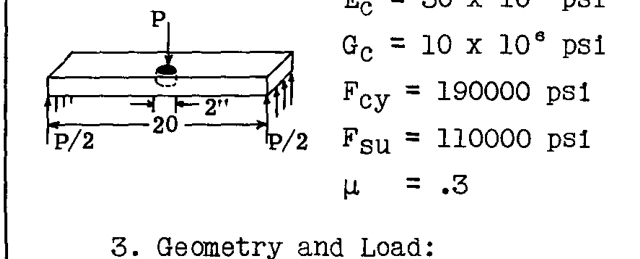

Given Geometry and Load

3. 形状および荷重:
   - パネル梁スパン $L = 20$ in.
   - 梁幅 $b = 5$ in.
   - インサートへの荷重 $= 10,000$ lb.
   - インサートサイズ $= 2$ in. 径
   - 中央部における許容曲げたわみ $\delta = 1.0$ in.

# C12.44 サンドイッチ構造と設計

$$F_{c\text{max}} = 150000 \text{ psi}$$

単純支持梁

計算:

1. パネル中央のたわみは次の式で表される。

$$\delta = \frac{PL^3}{48E_s I} = 1.0 \text{ in.}$$

$$E_s = E_{\text{secant}} = \frac{E}{1 + \frac{3}{7} \left( \frac{F_C}{F_{cy}} \right)^9} \quad \text{（Ref. Sec. C2.4）}$$

2. 最大曲げ応力は次の式で表される。

$$_f b = \frac{M}{I} \left( \frac{c + t_F}{2} \right) = 150000 \text{ psi}$$

$$M = \frac{P}{2} \times \frac{L}{2} = \frac{10000 \times 20}{4} = 50000 \text{ in. lb.}$$

$$I = 2t_F b \left( \frac{c + t_F}{2} \right)^2$$

3. $\delta$ と $f_b$ の式を結合し、 $t_F$ について解く

$$\delta = \frac{PL^3}{24E_s t_F (c + t_F)^2 b} = 1.0 \text{ in.}$$

$$f_b = \frac{M}{t_F b(c + t_F)} = 150000 \text{ psi}$$

$$c = \left[ \frac{PL^3}{824E_s t_F b} \right]^{1/2} - t_F, \quad c = \frac{M}{150000 t_F b} - t_F$$

$$\left[ \frac{PL^3}{824E_s t_F b} \right]^{1/2} = \frac{M}{150000 t_F b}$$

$$t_F = \left[ \frac{M}{150000} \right]^2 \frac{24E_s \delta}{PL^3 b}$$

$$E_s = \frac{30 \times 10^6}{1 + \frac{3}{7} \left( \frac{150000}{190000} \right)^9} = 28.5 \times 10^6 \text{ psi}$$

$$t_F = \left( \frac{50000}{150000} \right)^2 \frac{24 \times 28.5 \times 10^6}{10000 imes 8000 \times 6} = .105 \text{ in.}$$

$$c = \frac{M}{150000 t_F} - t_F = \frac{50000}{150000 \times .105 \times 5} - .105 = .527 \text{ in.}$$

4. 梁端部におけるコアの剪断力を計算する。

$$f_{sc} = \frac{P}{2cb} = \frac{5000}{.527 \times 5} = 1900 \text{ psi}$$

5. コアの要件を計算する。

$$F'_s = 1.307 \left( \frac{2t_C}{s} \right)^{1.34} \frac{F_{su}}{c^{.44}} \quad \text{式 C12.4.7 および C12.4.4 参照}$$

$$\frac{t_C}{s} = \left[ \frac{F'_s c^{.44}}{1.307 F_{su}} \right]^{.747} \times .5$$

$$\frac{t_C}{s} = \left[ \frac{.1900 \times .75}{1.307 \times 110000} \right]^{.747} \times .5 = .016$$

ろう付け剪断強度からセルサイズ $s$ を計算する。

$$F_{\text{sbr}} = 26000 \text{ psi}$$

$$F'_s = 1.25 \left( \frac{w}{s} \right) F_{\text{sbr}}$$

フィレット幅 $w = .016$

$$s = \frac{1.25 w F_{\text{sbr}}}{F'_s}$$

$$s = \frac{1.25 \times .016 \times 26000}{1900} = .285 \text{ in.}$$

6. インサートにおけるコアの剪断力を計算する。

$$f_{sc} = \frac{P \cdot I_m \cdot K}{\pi \cdot 2(c + t_F) I} \quad \text{式 C12.8.1 参照}$$

$$I_m = \frac{t_F(c + t_F)^2}{2}, \quad I = I_m + \frac{t_F^3}{6}$$

$a = \infty, K = 1.0$ と仮定する（図 C12.81）

$$f_{sc} = \frac{P(c + t_F)K}{\pi \cdot 4 \left[ \frac{(c + t_F)^2}{2} + \frac{t_F^2}{6} \right]}$$

$$f_{sc} = \frac{10000 \times .632 \times 1.0}{\pi \times 4 [.20 + .00184]} = 2490 \text{ psi}$$

この場合のパネルは全辺支持ではないため、計算された応力に対して調整を行う必要がある。剪断力はインサートの周囲の2/3のみで伝達されると仮定する。この場合、剪断応力は次のようになる。

$$f_{sc} = \frac{2490}{.667} = 3740 \text{ psi}$$

この場合、インサートの局所的な周囲に、より密度の高いコアが必要であり、上記と同様に決定できる。

$$t_C/s = .0317$$

7. 面のしわ寄りをチェックする。

$$\frac{F_{cw}}{\eta_s} = .43 \sqrt[3]{E_F E_C G_C} \cdot 5.1 \left( \frac{2t_C}{s} \right)^{2.955} \quad \text{式 C12.10.5 参照}$$

# C12.45

$$\frac{F_{cw}}{\eta_s} = .43 \times \left[ 30 \times 10^6 \times 30 \times 10^6 \times 10 \times 10^6 \times \frac{5.1 \times .000035}{1.0} \right]^{1/3}$$

$$\frac{F_{cw}}{\eta_s} = 502000 \text{ psi}$$

$$F_{cw} = 190000 \text{ psi} \quad \text{図 C12.5.7b 参照}$$

$$M.S. = \frac{190000}{150000} - 1 = .26$$

8. 面のセル間座屈またはディンプリングをチェックする。

$$\frac{F_{c1}}{\eta} = .75 E_F (t_F/s)^{3/2} \quad \text{式 C12.5.1 参照}$$

$$F_{c1} = 190000 \text{ psi} \quad \text{図 C12.5.2b 参照}$$

$$M.S. = \frac{190000}{150000} - 1 = .26$$

## C12.11.4 例題

次の例題は、一軸圧縮荷重を受ける波板コアパネルの設計パラメータの計算方法を示している。

与条件:

1. 材料: 7075-T6 アルミニウム
2. 特性:
   - $E = 10 \times 10^6$ psi
   - $G_C = 4 \times 10^6$ psi
   - $F_{cy} = 70000$ psi
   - $\mu = .3$
   - $G'_{cy} = 55000$ psi
3. 形状および荷重:
   - $a = 20$ in.
   - $b = 20$ in.
   - $N = 4000$ lb./in.
   - $F_{c\text{max}} = 60000$ psi

一軸圧縮荷重の場合、面板の厚さは波板の厚さと等しくなる。波板の最適な角度は $\theta = 60^\circ$ となる。

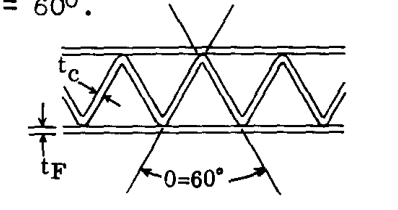

corrugation configuration

パネルは単純支持されている。

計算:

1. $$f_c = \frac{N}{2t_F + \frac{t_F}{\cos 60^\circ}}$$

$$t_F = \frac{N}{F_C (2 + \frac{1}{\cos 60^\circ})}$$

$$t_F = \frac{4000}{60000 \times 4} = .0167 \text{ in.}$$

2. 波板の深さ $c$ を計算する

$$c = \left[ \frac{2N_x b^2 (1 - \mu^2)}{K_x \pi^2 E_F t_F} \right]^{1/2} - t_F \quad \text{式 C12.10.18 参照}$$

$J = 5, K_x = 3.3$ と仮定する（図 C12.9.2 参照）

$$c = \left[ \frac{2 \times 4000 \times 400 (.91)}{3.3 \times \pi^2 \times 10 \times 10^6 \times .0167} \right]^{1/2} - .0167$$

```
 $c = .720$  in.
```

$$J = \frac{b^2 G'_{cy} c (1 - \mu^2) 2}{\pi^2 E_F t_F (c + t_F)^2}$$

$$J = \frac{400 \times 55000 \times .720 \times .91 \times 2}{\pi^2 10 \times 10^6 \times .0167 \times .542} = 32.2$$

```
 $K_x = 3.9$  （図 C12.9.2 参照）

 $c = .659$  in.,  $J = 34.8$

 $K_x = 3.90$  （図 C12.9.2 参照）

 $c = .659$  in.

 $c$  は十分に収束したため、 $c = .659$  in. を使用する。

パネル構成は以下の通りである。

 $t_F = .0167$  in.,  $c = .659$  in.

 $a = b = 20$  in.,  $\theta = 60^\circ$
```

3. 波板間の面板の座屈をチェックする。

$$F_{cr} = K_c E_F \left( \frac{t_F}{b} \right)^2$$

$$K_c = 4 \quad b = \frac{c}{\sin 60^\circ} = .76 \text{ in.}$$

$$F_{cr} = 4 \times 10 \times 10^6 \left( \frac{.0167}{.76} \right)^2 = 17100 \text{ psi}$$

$$M.S. = \frac{17100}{60000} - 1 = -.715$$

# C12.46 サンドイッチ構造と設計

波板間の座屈は不満足である。面板の厚さとコアの深さを変更する必要がある。

$$F_{cr} = F_C = \frac{N_x}{2t_F + \frac{t_F}{\cos 60^\circ}} = K_C E_F \left( \frac{t_F \sin 60^\circ}{c} \right)^2$$

$$c = \left[ \frac{K_C E_F (2t_F + \frac{t_F}{\cos 60^\circ})}{N_x} \right]^{1/2} t_F \sin 60^\circ$$

この $c$ の値を座屈方程式 C12.10.18 から導かれた $c$ と等しく置く。

$$\left[ \frac{K_C E_F (2t_F + \frac{t_F}{\cos 60^\circ})}{N_x} \right]^{1/2} t_F \sin 60^\circ = \left[ \frac{2N_x b^2 (1 - \mu^2)}{K_x \pi^2 E_F t_F} \right]^{1/2} - t_F$$

$$t_F^{1.5} \left[ \frac{K_C E_F (2 + \frac{1}{\cos 60^\circ})}{N_x} \right]^{1/2} \sin 60^\circ + t_F - \frac{1}{t_F^{0.5}} \left[ \frac{2N_x b^2 (1 - \mu^2)}{K_x \pi^2 E_F} \right]^{1/2} = 0$$

この方程式をプロットして $t_F$ について解く。

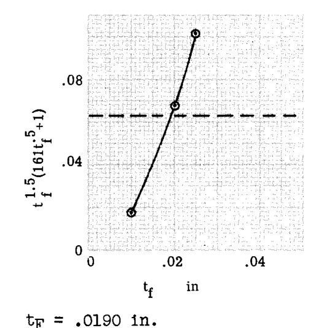

Plot to solve for t_F

$$t_F = .0190 \text{ in.}$$

$$c = \left[ \frac{K_C E_F t_F (2 + \frac{1}{\cos 60^\circ})}{N_x} \right]^{1/2} t_F \sin 60^\circ$$

$$c = \left[ \frac{4 \times 10 \times 10 \times .0190 \times 4}{4000} \right]^{1/2} \times .867$$

$$c = .46 \text{ in.}$$

## C12.11.5 例題

次の例題は、二軸圧縮および剪断荷重を受ける波板コアパネルの設計パラメータの計算方法を示している。

与条件:

1. 材料: PH15-7Mo (RH1050) 室温にて
2. 特性:
   - $E_F = 30 \times 10^6$ psi
   - $G_C = 10 \times 10^6$ psi
   - $F_{cy} = 190000$ psi
   - $\mu = .3$
   - $G'_{cy} = 150000$ psi
3. 形状および荷重:
   - $b = 20$ in.
   - $a = 40$ in.
   - $\theta = 60^\circ$
   - $N_x = 5000$ lb./in.
   - $N_{xy} = 2000$ lb./in.
   - $F_{c\text{max}} = 160000$ psi

面板厚さと波板厚さは等しく、パネルは単純支持されていると仮定する。

計算:

1. $$f_c = \frac{N_x}{2t_F + \frac{t_F}{\cos 60^\circ}} \quad \text{式 C12.10.17 参照}$$

$$f_s = \frac{N_{xy}}{2t_F + t_F \cos \theta} \quad \text{式 C12.10.20 参照}$$

波板の厚さの半分のみが剪断応力の計算に使用されることに注意する必要がある。これは、面板と波板における等しい剪断変形、およびその余分な長さによる波板材料の有効性の低下を考慮している。

$$f_{c\text{max}} = \frac{f_c}{2} + \sqrt{\left( \frac{f_c}{2} \right)^2 + f_s^2}$$

$$f_{c\text{max}} = \frac{N_x}{2t_F + \frac{t_F}{.5}} + \sqrt{\left( \frac{N_x}{2t_F + \frac{t_F}{.5}} \right)^2 + \left( \frac{N_{xy}}{2t_F + .5t_F} \right)^2}$$

# C12.47

$$f_{c\text{max}} = \frac{N_x}{4t_F} + \sqrt{\frac{N_x^2}{16t_F^2} + \frac{N_{xy}^2}{6.25t_F^2}}$$

$$t_F = \frac{N_x}{4f_{c\text{max}}} + \frac{1}{f_{c\text{max}}} \sqrt{\frac{N_x^2}{16} + \frac{N_{xy}^2}{6.25}}$$

$$t_F = \frac{5000}{4 \times 160000} + \frac{1}{160000} \sqrt{\frac{25 \times 10^6}{16} + \frac{4 \times 10^6}{6.25}}$$

$$t_F = .0171 \text{ in.}$$

2. 波板の深さ $c$ を計算する

$$N_x = \frac{K_x \pi^2 D}{b^2}, \quad N_{xy} = \frac{K_s \pi^2 D}{b^2}$$

$$\frac{N_x}{N_{xy}} = \frac{K_x}{K_s} = \frac{5000}{2000} = 2.5$$

$J = 20$ と仮定する

$K_x = 3.6, K_s = 1.44$ （図 C12.9.7c 参照）

$$c = \left[ \frac{2N_x b^2 (1 - \mu^2)}{K_x \pi^2 E_F t_F} \right]^{1/2} - t_F \quad \text{式 C12.10.18 参照}$$

$$c = \left[ \frac{2 \times 5000 \times 400 (.91)}{3.6 \times \pi^2 \times 30 \times 10^6 \times .0171} \right]^{1/2} - .0171$$

```
 $c = 1.398$  in.
```

$$J = \frac{b^2 G'_{cy} c (1 - \mu^2) 2}{\pi^2 E_F t_F (c + t_F)^2}$$

$$J = \frac{400 \times 150000 \times 1.398 \times .91 \times 2}{\pi^2 \times 30 \times 10^6 \times .0171 \times (1.398 + .0171)^2}$$

```
 $J = 15.1, \quad K_x = 3.5, \quad K_s = 1.40$

 $c = 1.413$  in.,  $\quad J = 14.95$

 $K_x = 3.5$

 $c = 1.413$  in.

 $c$  は十分に収束したため、 $c = 1.413$  in. を使用する。
```

3. 波板間の面板の座屈をチェックする。

$$F_{cr} = K_c E_F \left( \frac{t_F}{b} \right)^2$$

$$K_c = 4, \quad b = \frac{c}{\sin 60^\circ} = 1.64 \text{ in.}$$

$$F_{cr} = 4 \times 30 \times 10^6 \left( \frac{.0171}{1.64} \right)^2 = 13100 \text{ psi}$$

$$F_{scr} = K_s E_F \left( \frac{t_F}{b} \right)^2$$

しかし、パネルが波板間座屈の要件を満たさないことは明らかである。

4. 複合応力方程式は次の通りである。

$$R_c + R_s^2 = 1$$

$$\frac{f_c}{F_{cr}} + \left( \frac{f_s}{F_{scr}} \right)^2 = 1$$

$c$ について解く：

$$\frac{N_x}{4t_F K_c E_F \left( \frac{c}{t_F \sin 60^\circ} \right)^2} + \left[ \frac{N_{xy}}{2.5t_F K_s E_F \left( \frac{c}{t_F \sin 60^\circ} \right)^2} \right]^2 = 1$$

$$c^4 \left[ \frac{N_{xy}}{2.5 t_F K_s E_F (t_F \sin 60^\circ)^2} \right]^2 + c^2 \left[ \frac{N_x}{4 t_F K_c E_F (t_F \sin 60^\circ)^2} \right] - 1 = 0$$

$$c^2 = - \frac{\left[ \frac{N_x}{4 t_F K_c E_F (t_F \sin 60^\circ)^2} \right]}{2 \left[ \frac{N_{xy}}{2.5 t_F K_s E_F (t_F \sin 60^\circ)^2} \right]^2} \pm \frac{\sqrt{\left[ \frac{N_x}{4 t_F K_c E_F (t_F \sin 60^\circ)^2} \right]^2 + 4 \left[ \frac{N_{xy}}{2.5 t_F K_s E_F (t_F \sin 60^\circ)^2} \right]^2}}{2 \left[ \frac{N_{xy}}{2.5 t_F K_s E_F (t_F \sin 60^\circ)^2} \right]^2}$$

$$c^2 = \frac{ - \frac{N_x t_F E_F}{8K_c} + t_F E_F \sqrt{ \left( \frac{N_x}{4K_c} \right)^2 + 4 \left( \frac{N_{xy}}{2.5K_s} \right)^2 } }{ \left[ \frac{N_{xy}}{2.5 K_s t_F \sin 60^\circ} \right]^2 }$$

座屈方程式からの $c$ は（式 C12.10.18 参照）：

$$c = \left[ \frac{2 N_x b^2 (1 - \mu^2)}{K_x \pi^2 E_F t_F} \right]^{1/2} - t_F$$

5. これらの方程式を結合して $t_F$ について解く。

$$\left[ \frac{2 N_x b^2 (1 - \mu^2)}{K_x \pi^2 E_F t_F} \right]^{1/2} - t_F = \left[ \frac{ - \frac{N_x t_F E_F}{8K_c} + t_F E_F \sqrt{ \left( \frac{N_x}{4K_c} \right)^2 + 4 \left( \frac{N_{xy}}{2.5K_s} \right)^2 } }{ \left[ \frac{N_{xy}}{2.5 K_s t_F \sin 60^\circ} \right]^2 } \right]^{1/2}$$

# C12.48 サンドイッチ構造と設計

$$\left[ \frac{2 N_x b^2 (1 - \mu^2)}{K_x \pi^2 E_F t_F^3} \right]^{1/2} - \frac{4.66 K_s^2}{N_{xy}^2} \left[ - \frac{N_x t_F E_F}{8 K_c} + t_F E_F \sqrt{ \left( \frac{N_x}{4 K_c} \right)^2 + 4 \left( \frac{N_{xy}}{2.5 K_s} \right)^2 } \right]^{1/2} = 1 \quad \text{式 C12.11.1}$$

$K_x = 3.65, \quad K_c = 4, \quad K_s = 5.4$

方程式 C12.11.1 対 $t_F$ をプロットする。

$$\frac{.0581}{t_F^{1.5}} - 27.8 t_F^{1/2} = 1$$

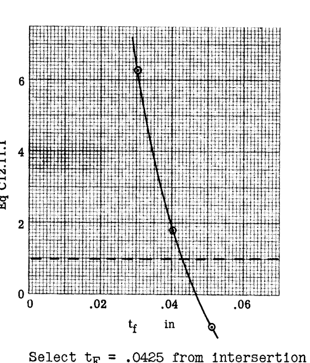

Plot Equation C12.11.1 vs. t_F

式 C12.11.1 と 1.0 の交点から $t_F = .0425$ を選択する。

$$c = \left[ \frac{2 N_x b^2 (1 - \mu^2)}{K_x \pi^2 E_F t_F} \right]^{1/2} - t_F$$

$$c = \left[ \frac{2 \times 5000 \times 400 \times .91}{3.65 \times \pi^2 \times 30 \times 10^6 \times .0425} \right]^{1/2} - .0425$$

$c = .848$ in.

## C12.11.6 例題

次の例題は、外側からの横圧力を受けるハニカムシリンダーの設計パラメータの計算方法を示している。

与条件:

1. 材料: 2024-T4 アルミニウム、5052 ハニカムコア
2. 特性:
   - $E_F = 10 \times 10^6$ psi
   - $G_C = 4 \times 10^6$ psi
   - $F_{cy} = 40000$ psi
   - $\mu = .3$
3. 形状および荷重:
   - $R = 25$ in.
   - $L = 100$ in.
   - $p = 20$ psi
   - $F_y = 10000$ psi

計算:

1. $$t_F = \frac{p R}{2 F_y} \quad \text{式 C12.10.27 参照}$$

$$t_F = \frac{20 \times 25}{2 \times 10000} = .025 \text{ in.}$$

2. Sec. C12.10.6.3 から $t_C/s$ 式を計算する

$$\gamma = \frac{f_y}{f_x} = 2, \quad \eta = 1.0$$

$$\frac{t_C}{s} = .5 \left[ \frac{2.81 F_y}{(E_F \eta^3 E_C G_C)^{1/3}} \right]^{1.015}$$

$$\frac{t_C}{s} = .5 \left[ \frac{2.81 \times 10000}{(10 \times 10^6 \times 1.0 \times 10 \times 10^6 \times 4 \times 10^6)^{1/3}} \right]^{1.015}$$

$$\frac{t_C}{s} = .00131$$

3. 図 C12.4.1 から $G'_C$ を計算する。

$$\rho'_C = 3 \frac{t_C}{s} \rho_C \quad \text{式 C12.4.5 参照}$$

$$\rho_C = .1 \text{ lb./in.}^3$$

$$\rho'_C = 3 \times .00131 \times .1 \times 1728$$

$$\rho'_C = .679 \text{ lb./ft.}^3$$

密度が低すぎるため、 $\rho'_C = 2$ lb./ft. $^3$ を使用する。

$G'_C = 23000$ psi

4. $n=6$ のとき、Sec. C12.10.6.3 の式からコア深さ $c$ を計算する。

$$M = 1 + n^2 \left( \frac{L}{2\pi R} \right)^2 = 1 + \left( \frac{6}{\pi} \right)^2 36 = 15.6$$

$$[ ] = \frac{4 L^2 (1 - \mu^2)}{\pi^2 E_F} = \frac{4 \times 10000 (.91)}{\pi^2 \times 10 \times 10^6} = .00368$$

# C12.49

$$\left\{ \right\} = \frac{2 t_F M}{G'_C} = \frac{2 \times .05 \times 15.6}{23000} = 6.8 \times 10^{-5}$$

$$( ) = \frac{M^2}{n^2 \beta^2 \left[ \frac{F_y}{\eta} - \frac{.00935 L^2 \pi^2 E_F}{n^2 \beta^2 R^2 M^2 (1 - \mu^2)} \right]}$$

$$( ) = \frac{243.5}{14.6 \left[ \frac{10000}{1} - \frac{.00935 \times 10000 \times \pi^2 \times 10 \times 10^6}{14.6 \times 625 \times 243.5 imes .91} \right]}$$

$$( ) = .00306 \quad \text{式 C12.10.16}$$

$$.00306 c^3 + c^2 [ .01224 t_F - 6.8 \times 10^{-5} ] + c [ .01530 t_F^2 - 13.6 \times 10^{-8} t_F - .00368 ] + [ .00612 t_F^3 - t_F^2 6.8 \times 10^{-5} - .00736 t_F ] = 0$$

$$.00306 c^3 + .000238 c^2 - .00368 c - .000184 = 0 \quad \text{式 C12.11.2}$$

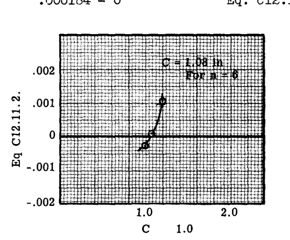

Eq C12.11.2 Plot

必要な $c$ の最大値を得るために、異なる $n$ の値を調査する必要がある。偶数の $n$ の値のみが適用可能である。

- $n = 8$ のとき、 $\quad c = 1.09$ in.
- $n = 10$ のとき、 $\quad c = .92$ in.

$c = 1.09$ in. を使用する必要がある。

5. 式 C12.10.1 を用いて最大セルサイズ $S$ を計算する。

$$S = .825 t_F \left( \frac{F_C}{E_F \eta} \right)^{-2/3}$$

$$F_C = \gamma F_y = 2.0 \times 10000 = 20000 \text{ psi}$$

$$S = .825 \times .25 \left( \frac{20000}{10 \times 10^6 \times 1} \right)^{-2/3}$$

$S = 1.25$ in.

## C12.11.7 例題

これまでに示した例題では、設計者が選択しなければならない特定の応力に対してサンドイッチパネルを設計した。多くの構造要素の場合、設計者は効率的に設計された構造に対して設計応力を選択できる。しかし、サンドイッチタイプの構造の場合、最良の効率を得るための応力を容易に選択することはできない。最適な応力レベルは、適用される荷重レベルの関数であることが証明されている。次の例題は、最適化の方法と、最適な応力レベルの直接的な決定方法を示している。この方法は、ハニカムカラム要素の設計で実証される。

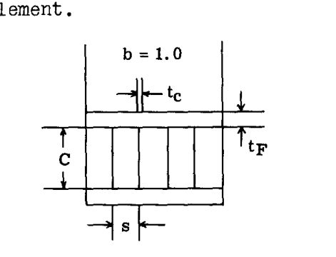

honeycomb column element

正方形セルハニカムの重量または断面積の式は、次のように書くことができる。

$$A = 2t_F + 2 \frac{t_C}{s} c$$

使用される許容応力式は次の通りである。

$$F_{cw} = .43 (E_F E_C G_C 5.1 \left( \frac{2t_C}{s} \right)^{2.955})^{1/3} \quad \text{Ref. Eq. C12.10.5}$$

$$F_{cc} = \frac{\pi^2 E}{(L/\rho)^2} \quad \rho^2 = \frac{I}{A}$$

$L =$ カラム長さ

$$I = 2t_F \left( \frac{c + t_F}{2} \right)^2 = \frac{t_F}{2} (c^2 + 2ct_F + t_F^2)$$

$$\rho = \frac{(c^2 + 2ct_F + t_F^2)}{4}$$

$$f_{\text{applied}} = \frac{N}{2t_F}$$

# C12.50 サンドイッチ構造と設計

$$F_{cw} = F_{\text{applied}} = \frac{N}{2t_F} = .43 (E_F E_C G_C 5.1 \left( \frac{2t_C}{s} \right)^{2.955})^{1/3}$$

$$\frac{2t_C}{s} = \left[ \frac{N}{.86 t_F (E_F E_C G_C 5.1)^{1/3}} \right]^{1.015}$$

$$\frac{2t_C}{s} = \left[ \frac{N}{t_F K_1} \right]^{1.015}$$

$$A = 2t_F + \left[ \frac{N}{t_F K_1} \right]^{1.015} c$$

$$F_{cc} = f_{\text{applied}} = \frac{N}{2t_F} = \frac{\pi^2 E(c^2 + 2ct_F + t_F^2)}{4L^2}$$

$$c^2 + 2ct_F + t_F^2 = \frac{2NL^2}{\pi^2 t_F E} = 0$$

$$c = -t_F + \frac{L}{\pi} \left( \frac{2N}{t_F E} \right)^{1/2}$$

$$A = 2t_F + \left[ \frac{N}{t_F K_1} \right]^{1.015} \left[ \frac{L}{\pi} \left( \frac{2N}{t_F E} \right)^{1/2} - t_F \right]$$

$$A = 2t_F + \frac{L}{\pi} \left( \frac{2}{E} \right)^{1/2} \frac{N^{1.515}}{t_F^{1.515} K_1^{1.015}} - \left( \frac{N}{K_1} \right)^{1.015} \frac{1}{t_F^{.015}}$$

単一変数に関する重量方程式を微分して、最小面積 $A$ を求めることができる。

$$\frac{dA}{dt_F} = 2 - \frac{L}{\pi} \left( \frac{2}{E} \right)^{1/2} \frac{N^{1.515}}{t_F^{2.515} K_1^{1.015}} + \left( \frac{N}{K_1} \right) t_F^{1.015} = 0$$

$$\frac{dA}{dt_F} = 2t_F^{2.515} - K_2 + K_3 t_F^{1.5} = 0$$

この方程式を $t_F$ について解くことで、最小のカラム重量または断面積に対する $t_F$ と応力レベルが得られる。

この方程式のさまざまな荷重レベルとカラム長さに対する結果を、図 C12.11.1 に示す。

図 C12.11.1 から明らかなように、低い荷重レベルおよび 7075-T6 アルミニウムの場合、降伏応力 $F_{cy}$ は最適ではない。また、曲線はカラム長さが最適応力レベルに及ぼす影響も示している。

ここで示された最適化問題は、比較的単純な問題である。このケースでは、面積方程式が面板厚さ $t_F$ に関して明示的に記述された。より多くの変数が関与する、より複雑な問題の場合、これは必ずしも当てはまらない。しかし、重量方程式を変数で表現し、偏微分による段階的な最適化を行うことができる。この方法は、著者による「熱勾配を伴う航空機構造の設計最適化」という論文（参考文献 14）で実証されている。

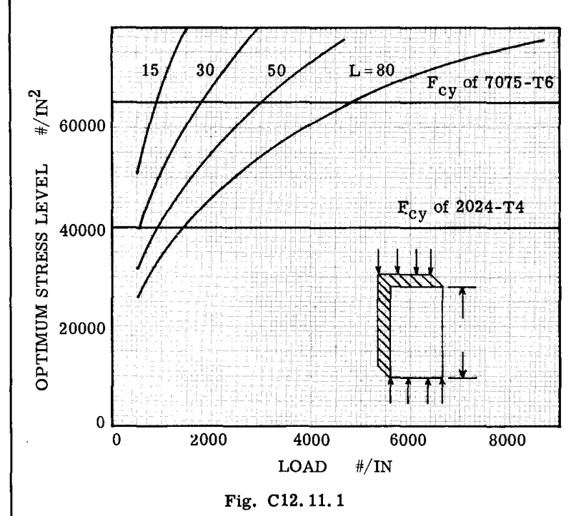

Fig. C12.11.1

## 参考文献

1. Forest Products Laboratory Report No. 1817, “Short Column Compressive Strength of Sandwich Construction”, C. B. Norris and W. J. Kommers, August 1950.
2. NA59-1597 Structural Development of Brazed Honeycomb Sandwich Construction for the Model F-108 Air Vehicle (North American Aviation, Inc.)
3. “Buckling of Sandwich-type Panels”, N. J. Hoff and S. E. Mautner - Journal of the Aeronautical Sciences, July 1945.
4. NAA-STR65 R.R. Anelmann and L. A. Harris (North American Aviation, Inc.).
5. ANC-23 Sandwich Construction for Aircraft.
6. NASA TN2601 “Compressive Buckling of Simply Supported Curved Plates and Cylinders of Sandwich Construction”, M. Stein and J. Meyers, January 1952.
7. NA60-1270 “Stability of Honeycomb Sandwich Cylinders”, M. O. Kiciman and D. Y. Konish.
8. Forest Products Laboratory Report No. 1583-B, "Compressive Buckling of Sandwich Panels

# C12.51

Having Dissimilar Facings of Unequal Thickness", W. S. Erickson and H. W. March, November 1958.

9. Forest Products Laboratory Report No. 1845, “Stress Induced in a Sandwich Panel by Load Applied at an Insert”, W. G. Youngquist and E. W. Kuenzi, March, 1955.
10. “Stability of Flat, Simply Supported Corrugated Core Sandwich Plates”, IAS Paper No. 59-87, L. A. Harris and R. R. Anelmann.
11. "A Small-Deflection Theory for Flat Sandwich Plates, NACA Report No. 898, 1948, C. Libove and S. B. Batdorf.
12. “The Stability Under Longitudinal Compression of Flat Symmetric Corrugated-Core Sandwich Plates”, NACA TN2279, April 1952, P. Seide.
13. Anderson, Melvin S. “Local Sustability of the Elements of a Truss-Core Sandwich Plate,” NASA Techn. Report TR-R-30. 1959.
14. “Design Optimization of Aircraft Structures with Thermal Gradients”, AIAA, J. Aircraft January 1964, Lloyd E. Hackman and James E. Richardson.

### サンドイッチ構造における代表的な継手、縁材、およびインサート

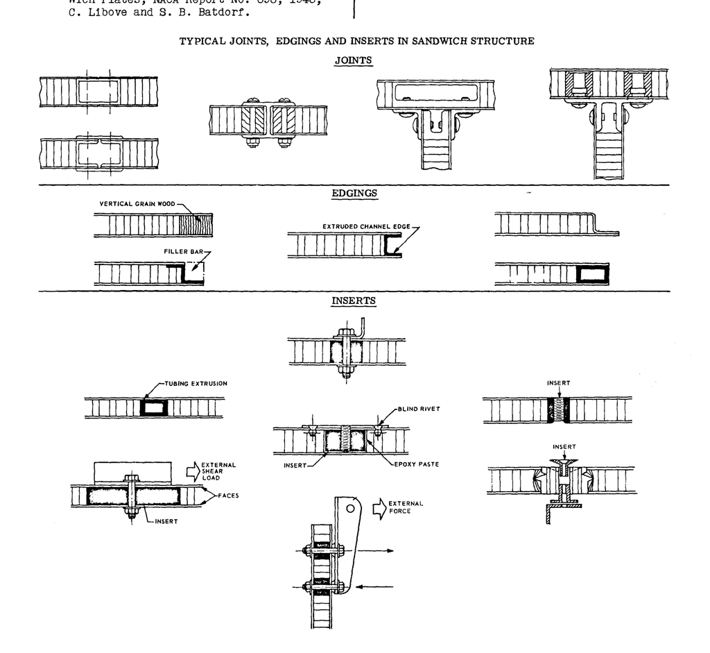

TYPICAL JOINTS, EDGINGS AND INSERTS IN SANDWICH STRUCTURE

# C12.52 サンドイッチ構造と設計

### 航空機構造に使用される代表的なサンドイッチ部品

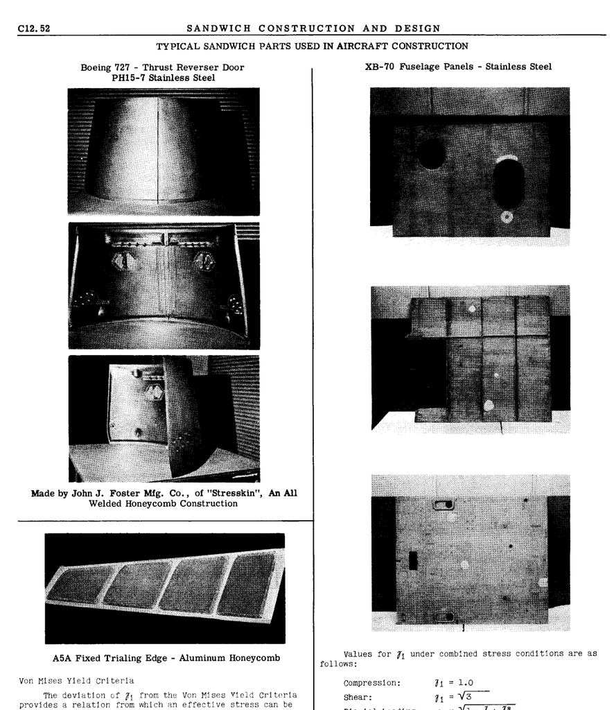

TYPICAL SANDWICH PARTS USED IN AIRCRAFT CONSTRUCTION

### フォン・ミーゼスの降伏基準

$\gamma_1$ のフォン・ミーゼスの降伏基準からの偏差は、材料の圧縮降伏と比較するための有効応力を導き出すことができる関係を提供する。フォン・ミーゼスの降伏基準は、材料の破壊基準を表すいくつかの形式の1つである。同じ基準の別の名称は、歪みエネルギー基準である。この基準は、さまざまな応力条件下での総塑性変形または降伏の開始を関連付ける。圧縮または引張りの場合、降伏応力は単純な試験によって明確に定義されるが、複合応力条件下での降伏応力レベルに関するデータは通常入手できない。したがって、この章で使用されているような、複合応力または非圧縮応力下の圧縮降伏応力を有効降伏応力に関連付けるための降伏関係が必要となる。

複合応力条件下での $\gamma_1$ の値は次の通りである。

圧縮:
$$\gamma_1 = 1.0$$

剪断:
$$\gamma_1 = \sqrt{3}$$

二軸荷重:
$$\gamma_1 = \sqrt{1 - \gamma + \gamma^2}$$
ここで $\gamma = f_y / f_x$

二軸圧縮と剪断:
$$\gamma_1 = \sqrt{1 - \gamma + \gamma^2 + 3\gamma_s^2}$$

$$\lambda = \frac{f_s}{f_x} \quad \lambda \le 1$$

$$\gamma_1 = \sqrt{\lambda^2 + (\beta \lambda)^2 - \gamma \lambda^2 + 3}$$

$$\lambda_1 = \frac{f_x}{f_s} \quad \lambda_1 \le 1$$